```python
import pandas as pd
import numpy as np
import seaborn as sns
import matplotlib.pyplot as plt
from pandas_profiling import ProfileReport
```

```python
data = pd.read_csv('./german_credit_data_dataset.csv')
data.isnull().sum().sum() #brak nulli
```

```
0
```

# Zamiana danych

Uznalem ze latwiej bedzie eksplorowac zbior jesli zamienie nic niemowiace oznaczenia na krotkie i opisowe.

```python
data.job = data.job.map({"A171" : "unemployed/ unskilled - non-resident","A172" : "unskilled - resident","A173" : "skilled employee / official","A174" : "management/ self-employed/highly qualified employee/ officer"})
data.telephone = data.telephone.map({"A191" : "no", "A192" : "yes"})
data.foreign_worker = data.foreign_worker.map({"A201":"yes", "A202": "no"})
```

```python
data.savings = data.savings.map({'A61' :'very low', 'A62' :'low', 'A63' : 'medium', 'A64': 'high', 'A65':'none or no data'})
```

```python
data.housing = data.housing.map({'A151' : 'rent', 'A152' : 'own', 'A153' : 'for free'})
```

```python
data.present_employment = data.present_employment.map({'A71' : 'no', 'A72' : 'short', 'A73' : 'medium', 'A74' :'long',
'A75' : 'very long'})
```

```python
data.purpose = data.purpose.map({'A40' : 'car (new)', 'A41' : 'car (used)', 'A42' : 'furniture/equipment', 'A43' : 'radio/television', 'A44' : 'domestic appliances', 'A45' :'repairs', 'A46':'education', 'A47':'vacation', 'A48':'retraining',
'A49' : 'business', 'A410' : 'others'})
```

```python
data.info()
data.customer_type = data.customer_type.map({1:'good',2:'bad'})#zmiana dla czytelnosci
```

```
<class 'pandas.core.frame.DataFrame'>
RangeIndex: 1000 entries, 0 to 999
Data columns (total 21 columns):
 #   Column                   Non-Null Count  Dtype
---  ------                   --------------  -----
 0   checking_account_status  1000 non-null   object
 1   duration                 1000 non-null   int64
 2   credit_history           1000 non-null   object
 3   purpose                  1000 non-null   object
 4   credit_amount            1000 non-null   float64
 5   savings                  1000 non-null   object
 6   present_employment       1000 non-null   object
 7   installment_rate         1000 non-null   float64
 8   personal                 1000 non-null   object
 9   other_debtors            1000 non-null   object
 10  present_residence        1000 non-null   float64
 11  property                 1000 non-null   object
 12  age                      1000 non-null   float64
 13  other_installment_plans  1000 non-null   object
 14  housing                  1000 non-null   object
 15  existing_credits         1000 non-null   float64
 16  job                      1000 non-null   object
 17  dependents               1000 non-null   int64
 18  telephone                1000 non-null   object
 19  foreign_worker           1000 non-null   object
 20  customer_type            1000 non-null   int64
dtypes: float64(5), int64(3), object(13)
memory usage: 164.2+ KB
```

```python
data.describe()
```

|  | duration | credit_amount | installment_rate | present_residence | age | existing_credits | dependents |
| --- | --- | --- | --- | --- | --- | --- | --- |
| count | 1000.000000 | 1000.000000 | 1000.000000 | 1000.000000 | 1000.000000 | 1000.000000 | 1000.000000 |
| mean | 20.903000 | 3271.258000 | 2.973000 | 2.845000 | 35.546000 | 1.407000 | 1.155000 |
| std | 12.058814 | 2822.736876 | 1.118715 | 1.103718 | 11.375469 | 0.577654 | 0.362086 |
| min | 4.000000 | 250.000000 | 1.000000 | 1.000000 | 19.000000 | 1.000000 | 1.000000 |
| 25% | 12.000000 | 1365.500000 | 2.000000 | 2.000000 | 27.000000 | 1.000000 | 1.000000 |
| 50% | 18.000000 | 2319.500000 | 3.000000 | 3.000000 | 33.000000 | 1.000000 | 1.000000 |
| 75% | 24.000000 | 3972.250000 | 4.000000 | 4.000000 | 42.000000 | 2.000000 | 1.000000 |
| max | 72.000000 | 18424.000000 | 4.000000 | 4.000000 | 75.000000 | 4.000000 | 2.000000 |

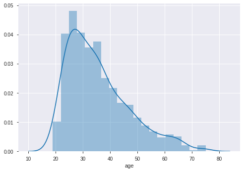

```python
sns.distplot(data.age)
```

Widac znaczna przewage ludzi w wieku mlodym oraz srednim

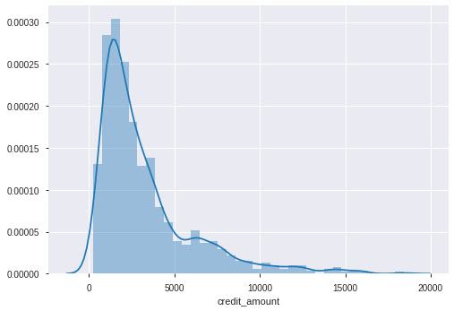

```python
sns.distplot(data.credit_amount)
```

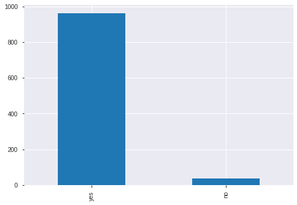

```python
data.foreign_worker.value_counts().plot(kind='bar')
```

Zdecydowana wiekszosc osob w naszych danych to osoby spoza Niemiec

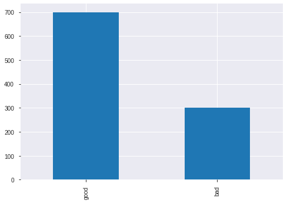

```python
data.customer_type.value_counts().plot(kind='bar')
```

Wiekszosc klientow zostala oceniona jako dobra, warto sie przyjrzec co zadecydowalo ze ktos zostal uznany jako zly klient

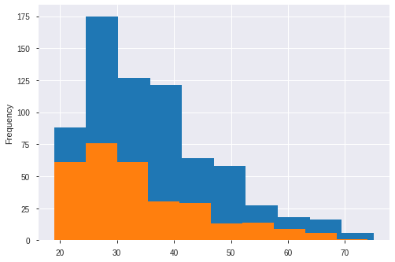

```python
ax = data.loc[data['customer_type']=='good'].age.plot(kind='hist')
ax1 = data[data['customer_type']=='bad'].age.plot(kind='hist')
```

Rozkład wieku wśrod ludzi ktorzy sa "dobrzy" a "zli" jest mniej wiecej podobny

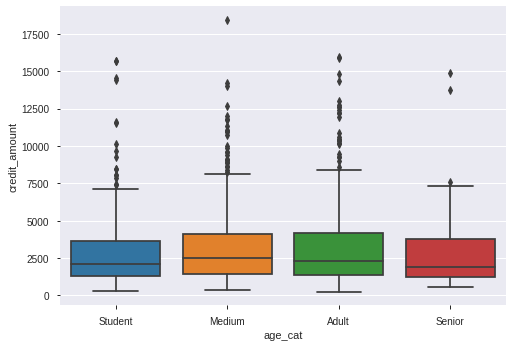

```python
interval = (19, 25, 35, 60, 75)#wiek waha sie od 19 do 75 lat

cats = ['Student', 'Medium', 'Adult', 'Senior']
data["age_cat"] = pd.cut(data.age, interval, labels=cats)
sns.boxplot(x = data.age_cat,y=data.credit_amount )
```

Ludzie w wieku srednim dostaja minimalnie wieksze kredyty niz w innym wieku

```python
val = ['A91','A93','A94'] #rozbijam kolumne personal na dane o plci oraz ewentualnym partnerze
data.loc[data['personal'] == 'A93', 'single'] = 1
data.loc[data['personal'] == 'A95', 'single'] = 1
data.loc[data['personal'].isin(val), 'sex'] = 1
data.single = data.single.fillna(0)
data.sex = data.sex.fillna(0)
```

```python
data.drop('personal',axis=1,inplace=True)
```

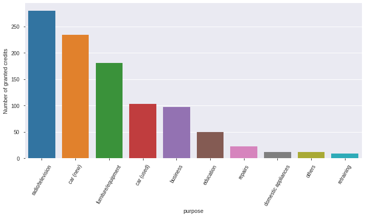

```python
n_credits = data.groupby("purpose")["age"].count().rename("count").reset_index()
n_credits.sort_values(by=["count"], ascending=False, inplace=True)

plt.figure(figsize=(10,6))
bar = sns.barplot(x="purpose",y="count",data=n_credits)
bar.set_xticklabels(bar.get_xticklabels(), rotation=60)
plt.ylabel("Number of granted credits")
plt.tight_layout()
```

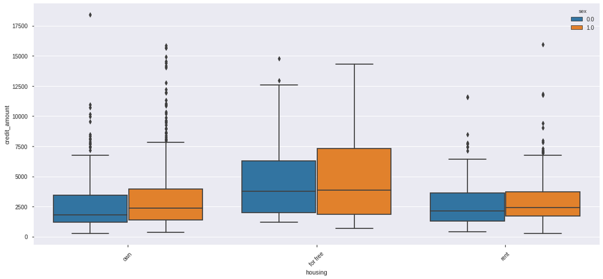

```python
def boxes(x,y,h,r=45):
    '''Pomocnicza funkcja sluzaca do rysowania boxplotow'''
    fig, ax = plt.subplots(figsize=(15,7))
    box = sns.boxplot(x=x,y=y, hue=h, data=data)
    box.set_xticklabels(box.get_xticklabels(), rotation=r)
    fig.subplots_adjust(bottom=0.2)
    plt.tight_layout()
boxes("housing","credit_amount","sex")
```

Ciekawa obserwacja z tego wykresu jest fakt ze mezczyzni maja srednio lekko wyzsze kredyty niz kobiety, a takze to ze w grupie "for free" - cokolwiek ona oznacza srednia kwota kredytu jest znacznie wyzsza niz w grupach o innym sposobie zamieszkania

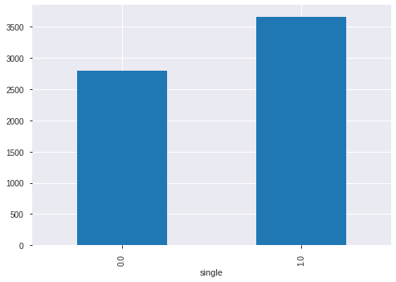

```python
data.groupby('single')['credit_amount'].mean().plot(kind='bar')
```

Single dostaja znacznie wyzsze kwoty kredytu

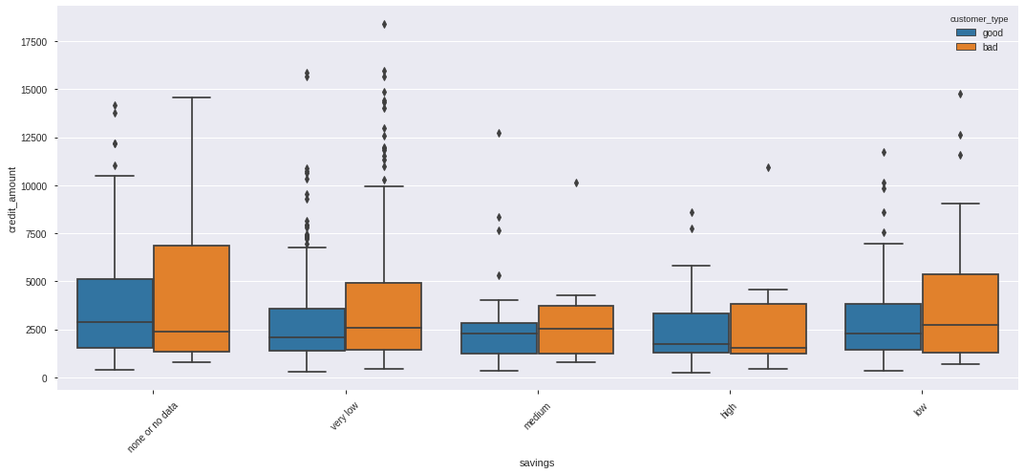

```python
boxes("savings","credit_amount",'customer_type')
```

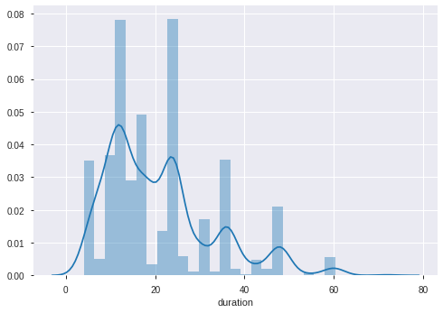

```python
sns.distplot(data.duration)
```

Wiekszosc kredytow jest brana raczej na dosc krotki czas

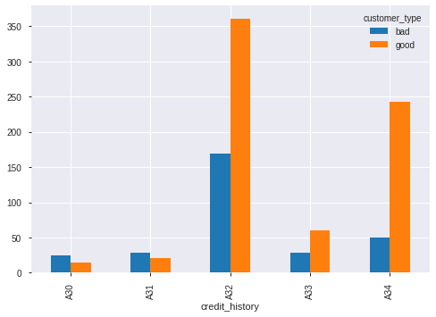

```python
data.groupby(['credit_history','customer_type'])['duration'].count().unstack().plot(kind='bar')
#A30: no credits taken/ all credits paid back duly, A31: all credits at this bank paid back duly, A32: existing credits paid back duly till now, A33: delay in paying off in the past, A34 : critical account/ other credits existing (not at this bank)
```

Z danych wynika ze bank najchetniej klasyfikuje klientow jak zlych głownie przez brak zdolnosci kredytowej, jednakze ciezko wysuwac jednoznaczne wnioski gdyz probka jest dosc mala. Jak mozna bylo sie spodziewac bank dosc chetnie klasyfikuje klientow jako dobrych jesli ci placa na czas

```python
data.installment_rate.value_counts().plot(kind='bar')
```

[figure not shown]

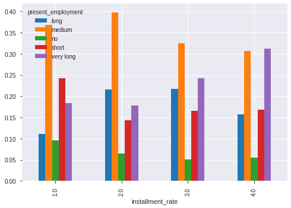

```python
x = data.groupby(['installment_rate','present_employment'])['duration'].count()
x = x.groupby(level=[0]).apply(lambda g: g / g.sum())
x.unstack().plot(kind='bar')
```

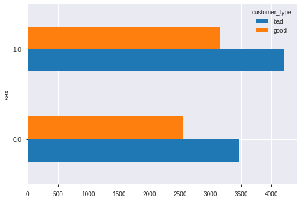

```python
data.groupby(['sex','customer_type'])['credit_amount'].mean().unstack().plot(kind='barh')
```

Widac ze mezczyzni otrzymuja wyzsze kredyty, a takze co zaskakujace w przypadku obu płci konsumenci o zlym ratingu maja wieksze kredyty

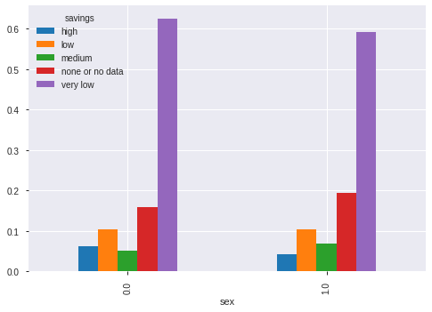

```python
x = data.groupby('sex')['savings'].value_counts()
x = x.groupby(level=[0]).apply(lambda g: g / g.sum())
x.unstack().plot(kind='bar')
```

W przypadku obu plci przewazaja (co smutne) bardzo niskie oszczednosci, a zadna z plci nie dominuje

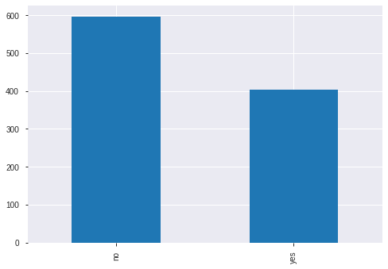

```python
data.telephone.value_counts().plot(kind='bar')
```

Wiekszosc ludzi nie posiada telefonu( co w roku 1994 raczej nie dziwi)

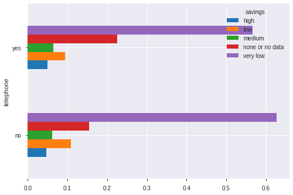

```python
x= data.groupby('telephone')['savings'].value_counts()
x = x.groupby(level=[0]).apply(lambda g: g / g.sum())
x.unstack().plot(kind='barh')
```

Co calkiem ciekawe posiadanie telefonu zdaje się w zaden konkretny sposob nie wplywac na ilosc posiadanych oszczednosci

```python
prof = ProfileReport(data)
prof.to_file(output_file='output.html')
```

```python
corr = data.corr()
ax=sns.heatmap(corr,
            xticklabels=corr.columns,
            yticklabels=corr.columns, annot=True)

bottom, top = ax.get_ylim()
ax.set_ylim(bottom + 0.5, top - 0.5)
ax.set_title('Korelacja zmiennych')
plt.show()
```

[output not shown]